# Reproducible Structural Equation Modeling

Jason M. Bryer, Ph.D.

December 12, 2014

# Overview

1. What is Reproducible Research
2. Organizing Project
3. Conducting SEM in R
4. Sharing Research

# Why Conduct Reproducible Research

- For collaboration.
- To share knowledge not only of findings but of the process (including “failed” studies).
- Allow other researchers to verify results.
- Create a library/community of data for other studies.
- Avoid the embarrassment of Reinhart and Rogoff (see e.g. [Businessweek](http://www.businessweek.com/articles/2013-04-18/faq-reinhart-rogoff-and-the-excel-error-that-changed-history))

### The tools used for this project:

- [R](http://www.r-project.org), [RStudio](http://rstudio.com) and the [`lavaan`](http://lavaan.ugent.be/) package.
- [Github](http://github.com)
- [Open Science Framework](https://osf.io)

# File Structure

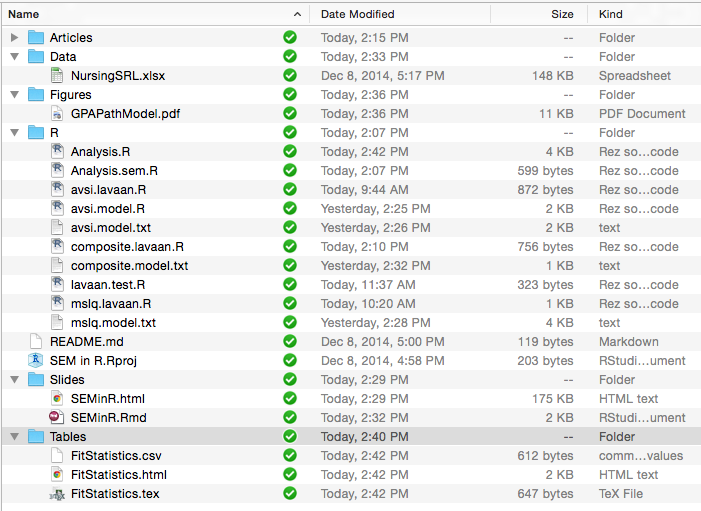

# Data Preparation

The data for this example come from Nagelsmith, Bryer, and Yan (2012). It measures motivation, volitional control, and GPA for nursing students in an online college.

```r
srl <- read.xls('../Data/NursingSRL.xlsx', sheet=1)
names(srl)
```

```
 [1] "id"          "age"         "status"      "statusdate"  "enrolldate"
 [6] "enrolled"    "gpa"         "coregpa"     "nursinggpa"  "genedgpa"
[11] "race"        "income"      "gender"      "age_A"       "mslq1"
[16] "mslq2"       "mslq3"       "mslq4"       "mslq5"       "mslq6"
[21] "mslq7"       "mslq8"       "mslq9"       "mslq10"      "mslq11"
[26] "mslq12"      "mslq13"      "mslq14"      "mslq15"      "mslq16"
[31] "mslq17"      "mslq18"      "mslq19"      "mslq20"      "mslq21"
[36] "mslq22"      "mslq23"      "mslq24"      "mslq25"      "mslq26"
[41] "mslq27"      "mslq28"      "mslq29"      "mslq30"      "mslq31"
[46] "avsi32"      "avsi33"      "avsi34"      "avsi35"      "avsi36"
[51] "avsi37"      "avsi38"      "avsi39"      "avsi40"      "avsi41"
[56] "avsi42"      "avsi43"      "avsi44"      "avsi45"      "avsi46"
[61] "avsi47"      "avsi48"      "avsi49"      "avsi50"      "avsi51"
[66] "mslqtotal"   "mslqvctotal" "mslqvcigo"   "mslqvcego"   "mslqvctv"
[71] "mslqectotal" "mslqeccolb"  "mslqecse"    "mslqactotal" "avsitotal"
[76] "avsisee"     "avsinbi"     "avsisra"     "highachieve"
```

# Instruments

Academic Volitional Strategies Inventory (AVSI) - 20 items measuring three factors:

- Stress Reducing Actions
- Negative-Based Incentives
- Self-Efficacy Enhancement

Motivated Strategies for Learning Questionnaire (MSLQ) - 31 items measuring six factors:

- Intrinsic Goal Orientation
- Task Value
- Test Anxiety
- Extrinsic Goal Orientation
- Control of Learning Beliefs
- Self-Efficacy

# Analysis Outline

1. Perform three confirmatory analyses
   1. AVSI
   2. MSLQ
   3. Composite
2. Estimate structural model predicting GPA

# Defining Models

Using `lavaan`, the model is specified as a character vector and for organizational purposes, saved to an external file.

```r
source('../R/avsi.lavaan.R')
source('../R/mslq.lavaan.R')
source('../R/composite.lavaan.R')
```

The baseline model for the AVSI measure:

```
    # Measurement model
    StressReducingActions =~ avsi35 + avsi40 + avsi45 + avsi47
    NegativeBasedIncentives =~ avsi34 + avsi38 + avsi39 + avsi42 + avsi44 + avsi46 + avsi48
    SelfEfficacyEnhancement =~ avsi32 + avsi33 + avsi36 + avsi37 + avsi41 + avsi43 + avsi49 + avsi50 + avsi51
```

# AVSI CFA Model

The `cfa` function will conduct the confirmatory factor analysis and `summary` function prints all the output.

```r
avsi.fit0 <- lavaan::cfa(avsi.model0.lavaan, data=srl)
summary(avsi.fit0, fit.measures=TRUE)
```

```
lavaan (0.5-17) converged normally after  53 iterations

  Number of observations                           297

  Estimator                                         ML
  Minimum Function Test Statistic              550.975
  Degrees of freedom                               167
  P-value (Chi-square)                           0.000

Model test baseline model:

  Minimum Function Test Statistic             1656.162
  Degrees of freedom                               190
  P-value                                        0.000

User model versus baseline model:

  Comparative Fit Index (CFI)                    0.738
  Tucker-Lewis Index (TLI)                       0.702

Loglikelihood and Information Criteria:

  Loglikelihood user model (H0)             -10252.991
  Loglikelihood unrestricted model (H1)      -9977.504

  Number of free parameters                         43
  Akaike (AIC)                               20591.982
  Bayesian (BIC)                             20750.813
  Sample-size adjusted Bayesian (BIC)        20614.445

Root Mean Square Error of Approximation:

  RMSEA                                          0.088
  90 Percent Confidence Interval          0.080  0.096
  P-value RMSEA <= 0.05                          0.000

Standardized Root Mean Square Residual:

  SRMR                                           0.086

```

[output cut: 47 more lines]

```
    avsi44            2.030    0.188
    avsi46            1.038    0.093
    avsi48            1.618    0.168
    avsi32            2.623    0.222
    avsi33            1.304    0.118
    avsi36            0.887    0.082
    avsi37            1.299    0.114
    avsi41            0.670    0.058
    avsi43            1.091    0.104
    avsi49            0.999    0.091
    avsi50            1.532    0.145
    avsi51            2.670    0.227
    StrssRdcngAct     0.405    0.145
    NgtvBsdIncntv     0.717    0.163
    SlfEffccyEnhn     0.361    0.128
```

# AVSI CFA Model (cont.)

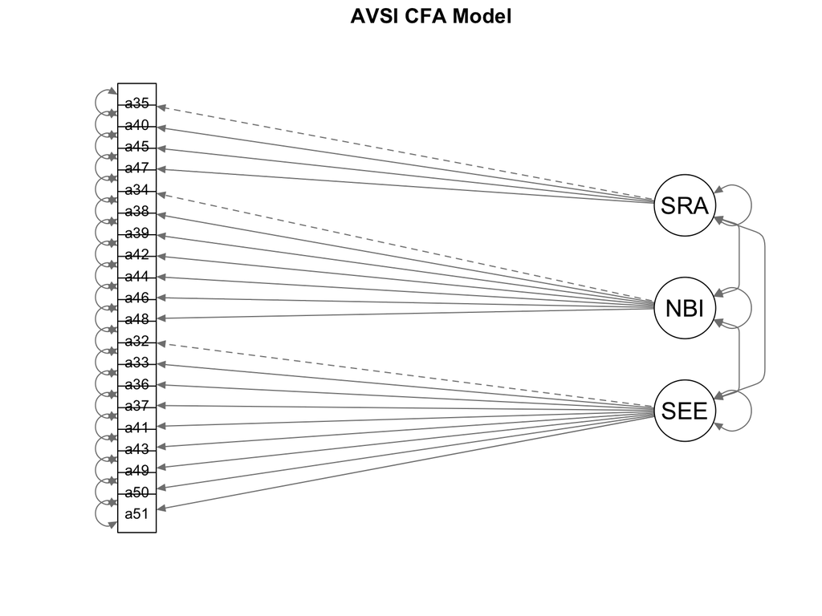

```r
semPaths(avsi.fit0, rotation=4, curvePivot=TRUE)
title('AVSI CFA Model', line=3)
```

# Estimating More Models

For this study, we modified our models to achieve better fit. Model 2 is our final model in all cases.

```r
avsi.fit0 <- lavaan::cfa(avsi.model0.lavaan, data=srl)
avsi.fit2 <- lavaan::cfa(avsi.model2.lavaan, data=srl)
mslq.fit0 <- lavaan::cfa(mslq.model0.lavaan, data=srl)
mslq.fit2 <- lavaan::cfa(mslq.model2.lavaan, data=srl)
comp.fit0 <- lavaan::cfa(comp.model0.lavaan, data=srl)
comp.fit2 <- lavaan::cfa(comp.model2.lavaan, data=srl)
```

# Modeling GPA

One of our research goals is to understand the relationship between motivation and volition as predictors of GPA. The `sem` function will estimate the structural equation model.

```r
gpa.fit <- lavaan::sem(sem.model.lavaan, data=srl)
summary(gpa.fit, fit.measures=TRUE)
```

```
lavaan (0.5-17) converged normally after 149 iterations

  Number of observations                           297

  Estimator                                         ML
  Minimum Function Test Statistic               38.532
  Degrees of freedom                                19
  P-value (Chi-square)                           0.005

Model test baseline model:

  Minimum Function Test Statistic              788.082
  Degrees of freedom                                36
  P-value                                        0.000

User model versus baseline model:

  Comparative Fit Index (CFI)                    0.974
  Tucker-Lewis Index (TLI)                       0.951

Loglikelihood and Information Criteria:

  Loglikelihood user model (H0)              -7083.768
  Loglikelihood unrestricted model (H1)      -7064.502

  Number of free parameters                         26
  Akaike (AIC)                               14219.537
  Bayesian (BIC)                             14315.574
  Sample-size adjusted Bayesian (BIC)        14233.119

Root Mean Square Error of Approximation:

  RMSEA                                          0.059
  90 Percent Confidence Interval          0.031  0.086
  P-value RMSEA <= 0.05                          0.268

Standardized Root Mean Square Residual:

  SRMR                                           0.051

```

[output cut: 36 more lines]

```

Variances:
    mslqvcigo         6.834    0.828
    mslqvcego        21.460    1.813
    mslqvctv          8.114    1.395
    mslqeccolb        7.914    0.768
    mslqecse         18.059    3.012
    avsisee          10.053    3.905
    avsinbi          36.240    3.365
    avsisra          11.657    1.204
    gpa               0.146    0.012
    VC                3.635    0.974
    EC               -0.943    0.985
    V                40.408    5.641
    M                 5.071    1.208
```

# Model GPA (cont.)

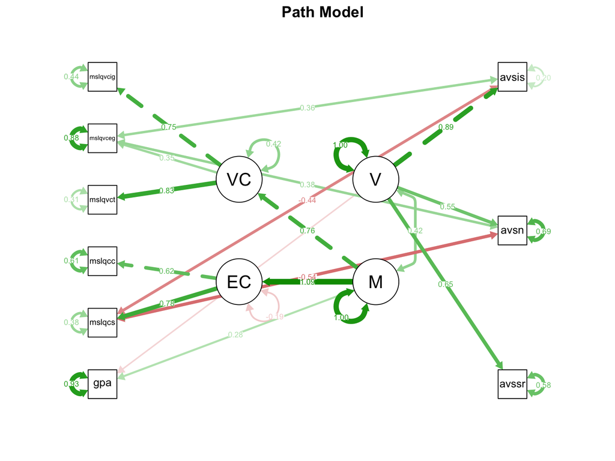

```r
semPaths(gpa.fit, what='std', rotation=4, curvePivot=TRUE, title=FALSE)
title('Path Model', line=3)
```

# Building Tables

The `summary` function provides a large amount of information. For our final report we will want to limit the output to only the desired statistics. We can extract the fit statistics we wish to use and combine them into a single `data.frame`.

```r
fits <- c('chisq','df','TLI','CFI','RMSEA')
fit.stats <- data.frame(
    MSLQ0 = as.numeric(fitMeasures(mslq.fit0, fits)),
    MSLQ2 = as.numeric(fitMeasures(mslq.fit2, fits)),
    AVSI0 = as.numeric(fitMeasures(avsi.fit0, fits)),
    AVSI2 = as.numeric(fitMeasures(avsi.fit2, fits)),
    Comp0 = as.numeric(fitMeasures(comp.fit0, fits)),
    Comp2 = as.numeric(fitMeasures(comp.fit2, fits)),
    GPA   = as.numeric(fitMeasures(gpa.fit, fits))
)
row.names(fit.stats) <- fits
fit.stats
```

```
        MSLQ0   MSLQ2   AVSI0   AVSI2  Comp0  Comp2    GPA
chisq 1.2e+03 815.799 550.975 357.068 306.15 24.186 38.532
df    4.2e+02 399.000 167.000 154.000  18.00 13.000 19.000
TLI   8.1e-01   0.894   0.702   0.829   0.39  0.967  0.951
CFI   8.3e-01   0.909   0.738   0.861   0.61  0.985  0.974
RMSEA 7.9e-02   0.059   0.088   0.067   0.23  0.054  0.059
```

# Results: Fit Statistics

Using the `xtable` function, we can create a LaTeX or HTML table to include in our report.

```r
x <- xtable(fit.stats, label='fitstats',
            caption='Model Fit Statistics for Confirmatory Factor Analysis')
```

Model Fit Statistics for Confirmatory Factor Analysis

|  | MSLQ0 | MSLQ2 | AVSI0 | AVSI2 | Comp0 | Comp2 | GPA |
| --- | --- | --- | --- | --- | --- | --- | --- |
| chisq | 1202.90 | 815.80 | 550.97 | 357.07 | 306.15 | 24.19 | 38.53 |
| df | 419.00 | 399.00 | 167.00 | 154.00 | 18.00 | 13.00 | 19.00 |
| TLI | 0.81 | 0.89 | 0.70 | 0.83 | 0.39 | 0.97 | 0.95 |
| CFI | 0.83 | 0.91 | 0.74 | 0.86 | 0.61 | 0.98 | 0.97 |
| RMSEA | 0.08 | 0.06 | 0.09 | 0.07 | 0.23 | 0.05 | 0.06 |

# Results: Path Coefficients

We can also extract any path coefficients we are interested in.

```r
pe <- parameterEstimates(gpa.fit)
pe[pe$lhs == 'gpa',]
```

```
  lhs op rhs    est    se    z pvalue ci.lower ci.upper
1 gpa  ~   M  0.050 0.013  3.7  0.000    0.023    0.076
2 gpa  ~   V -0.009 0.005 -2.1  0.039   -0.018    0.000
3 gpa ~~ gpa  0.146 0.012 11.8  0.000    0.122    0.171
```

# Warnings About SEM

#### Model Fit

There is not agreed upon threshold for determining good model fit but some guidelines are available (c.f. Hooper, Coughlan, & Mullen, 2008).

#### Model fit versus Parsimony

Most software (`lavaan` included) will provide modification indices that suggest modifications that can be made to increase model fit, although these will increase model fit, they also reduce the parsimony of the model.

#### Making Causal Estimates

> “I like to say is that in observational settings I feel I can interpret at most one variable causally. The difficulty is that it’s hard to control for things that happen after the variable that you’re thinking of as the ‘treatment.’” Gelman (2009)

http://andrewgelman.com/2009/09/09/why_am_i_skepti/

# Sharing Results: Github

http://github.com/jbryer/NursingSRL

[figure not shown]

# Sharing Results: Open Science Framework

https://osf.io/g4xf9/

[figure not shown]

# Thank You

### Jason Bryer, Ph.D. (jason@bryer.org, www.bryer.org)

- Github: http://github.com/jbryer/NursingSRL
- Open Science Framework: https://osf.io/g4xf9/

# References

Hooper, D., Coughlan, J., & Mullen, M.R. (2008). Structural equation modeling: Guidelines for determining model fit. *The Electronic Journal of Business Research Methods, 6*(1), 53-60.

Jöreskog, K., & Sörbom, D. (1993). *Lisrel 8: Structural Equation Modeling with the SIMPLIS Command Language.* Lincolnwood, IL: Scientific Software International, Inc.

Nagelsmith, L., Bryer, J., & Yan, Z. (2012). Measuring motivation and volition of nursing students in nontraditional learning environments. *Journal of Nursing Measurement, 20*(2), 90-112.

R Core Team (2014). R: A language and environment for statistical computing. R Foundation for Statistical Computing, Vienna, Austria.

Rosseel, Y. (2012). `lavaan`: An R package for structural equation modeling. *Journal of Statstical Software, 48*(2).

Epskamp, S. (2014). `semPlot`: Path diagrams and visual analysis of various SEM packages’ output. R package version 1.0.1.